```python
import pandas as pd
import numpy as np
import matplotlib.pyplot as plt
import seaborn as sns
import pdb
%matplotlib inline
```

# Data wrangling

#### VARIABLE DESCRIPTIONS:

| column | description |
| --- | --- |
| survival | Survival (0 = No; 1 = Yes) |
| pclass | Passenger Class (1 = 1st; 2 = 2nd; 3 = 3rd) |
| name | Name |
| sex | Sex |
| age | Age |
| sibsp | Number of Siblings/Spouses Aboard |
| parch | Number of Parents/Children Aboard |
| ticket | Ticket Number |
| fare | Passenger Fare |
| cabin | Cabin |
| embarked | Port of Embarkation (C = Cherbourg; Q = Queenstown; S = Southampton) |

#### SPECIAL NOTES:

- Pclass is a proxy for socio-economic status (SES)
  - 1st ~ Upper; 2nd ~ Middle; 3rd ~ Lower
- Age is in Years; Fractional if Age less than One (1)
  - If the Age is Estimated, it is in the form xx.5

With respect to the family relation variables (i.e. sibsp and parch) some relations were ignored. The following are the definitions used for sibsp and parch.

```
Sibling:  Brother, Sister, Stepbrother, or Stepsister of Passenger Aboard Titanic
Spouse:   Husband or Wife of Passenger Aboard Titanic (Mistresses and Fiances Ignored)
Parent:   Mother or Father of Passenger Aboard Titanic
Child:    Son, Daughter, Stepson, or Stepdaughter of Passenger Aboard Titanic
```

Other family relatives excluded from this study include cousins, nephews/nieces, aunts/uncles, and in-laws. Some children travelled only with a nanny, therefore parch=0 for them. As well, some travelled with very close friends or neighbors in a village, however, the definitions do not support such relations.

```python
raw_data = pd.read_csv("./titanic.csv")
raw_data.head()
```

|  | PassengerId | Survived | Pclass | Name | Sex | Age | SibSp | Parch | Ticket | Fare | Cabin | Embarked |
| --- | --- | --- | --- | --- | --- | --- | --- | --- | --- | --- | --- | --- |
| 0 | 1 | 0 | 3 | Braund, Mr. Owen Harris | male | 22.0 | 1 | 0 | A/5 21171 | 7.2500 | NaN | S |
| 1 | 2 | 1 | 1 | Cumings, Mrs. John Bradley (Florence Briggs Th... | female | 38.0 | 1 | 0 | PC 17599 | 71.2833 | C85 | C |
| 2 | 3 | 1 | 3 | Heikkinen, Miss. Laina | female | 26.0 | 0 | 0 | STON/O2. 3101282 | 7.9250 | NaN | S |
| 3 | 4 | 1 | 1 | Futrelle, Mrs. Jacques Heath (Lily May Peel) | female | 35.0 | 1 | 0 | 113803 | 53.1000 | C123 | S |
| 4 | 5 | 0 | 3 | Allen, Mr. William Henry | male | 35.0 | 0 | 0 | 373450 | 8.0500 | NaN | S |

### Sanitize raw Titanic data

- Split name column into relevant parts: last name, first name, and title

```python
def split_names(name):
    last, first = name.split(", ") # extract last name from name column value
    title_and_first = first.split(". ") # separate title and first name
    if len(title_and_first) == 2:
        return last, title_and_first[1], title_and_first[0]
    else:
        return last, " ".join(title_and_first[1:]), title_and_first[0] # account for rw 513 with middle initial

split_names = raw_data["Name"].apply(lambda x: pd.Series(split_names(x))).rename(columns={2: "Title", 1: "First", 0: "Last"})
sanitized_data = pd.concat([split_names, raw_data[["PassengerId", "Survived", "Pclass", "Sex", "Age", "SibSp", "Parch", "Ticket", "Fare", "Cabin", "Embarked"]]], axis=1)
```

- Replace "Embarked" abbreviations with full port name

```python
def check_col_values(col): # use to confirm lack of unexpected variation in data
    return sanitized_data[col].unique()

def get_full_port(port):
    if port == "C":
        return "Cherbourg"
    elif port == "Q":
        return "Queenstown"
    elif port == "S":
        return "Southhampton"
    else:
        return port # just in case cell is run after initial changes applied

check_col_values("Embarked") # confirms only Q, S, C in dataset
sanitized_data["Embarked"] = sanitized_data["Embarked"].apply(get_full_port)
```

- Replace "Pclass" abbreviations with full class name

```python
def get_full_class(pclass):
    if pclass == 1:
        return "Upper"
    elif pclass == 2:
        return "Middle"
    elif pclass == 3:
        return "Lower"
    else:
        return pclass # just in case cell is run after initial changes applied

check_col_values("Pclass") # confirms only 1, 2, 3 in dataset
sanitized_data["Pclass"] = sanitized_data["Pclass"].apply(get_full_class)
```

```python
sanitized_data.head()
```

|  | Last | First | Title | PassengerId | Survived | Pclass | Sex | Age | SibSp | Parch | Ticket | Fare | Cabin | Embarked |
| --- | --- | --- | --- | --- | --- | --- | --- | --- | --- | --- | --- | --- | --- | --- |
| 0 | Braund | Owen Harris | Mr | 1 | 0 | Lower | male | 22.0 | 1 | 0 | A/5 21171 | 7.2500 | NaN | Southhampton |
| 1 | Cumings | John Bradley (Florence Briggs Thayer) | Mrs | 2 | 1 | Upper | female | 38.0 | 1 | 0 | PC 17599 | 71.2833 | C85 | Cherbourg |
| 2 | Heikkinen | Laina | Miss | 3 | 1 | Lower | female | 26.0 | 0 | 0 | STON/O2. 3101282 | 7.9250 | NaN | Southhampton |
| 3 | Futrelle | Jacques Heath (Lily May Peel) | Mrs | 4 | 1 | Upper | female | 35.0 | 1 | 0 | 113803 | 53.1000 | C123 | Southhampton |
| 4 | Allen | William Henry | Mr | 5 | 0 | Lower | male | 35.0 | 0 | 0 | 373450 | 8.0500 | NaN | Southhampton |

# Analysis Questions

### Are there any differences in the price of tickets between passengers who embarked at the same port and were in the same class?

- If so, by how much do they differ, fare-wise?

##### Explore data: columns Pclass, Embarked, Fare

```
!: There are many more lower class passengers than middle or upper; in fact, there are more passengers in the lower class than the upper and middle classes combined.
```

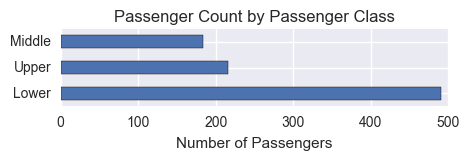

```python
num_class = sanitized_data["Pclass"].value_counts()

# plot counts of passengers by class
num_class.plot(kind="barh", figsize=(5, 1), title="Passenger Count by Passenger Class").set_xlabel("Number of Passengers")

# checking to see whether number of other two classes is more or less than number of lower class passengers
num_class["Lower"] > num_class["Upper"] + num_class["Middle"]

print "!: There are many more lower class passengers than middle or upper; in fact, there are more passengers in the lower class than the upper and middle classes combined."
```

```
!: It's clear that Southhampton is the most common port of embarkation in the dataset.
```

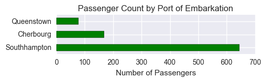

```python
num_port = sanitized_data["Embarked"].value_counts()
num_port.plot(kind="barh", color="green", figsize=(5, 1), title="Passenger Count by Port of Embarkation").set_xlabel("Number of Passengers")
print "!: It's clear that Southhampton is the most common port of embarkation in the dataset."
```

```
!: the greatest number of passengers purchased fares between $0 and $50.
```

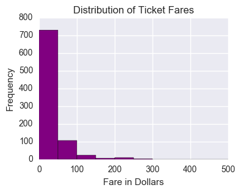

```python
fares = sanitized_data["Fare"]
fares.plot(kind="hist", color="purple", bins=range(0, 550, 50), figsize=(4, 3), title="Distribution of Ticket Fares").set_xlabel("Fare in Dollars")
print "!: the greatest number of passengers purchased fares between $0 and $50."
```

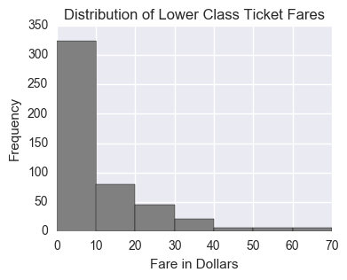

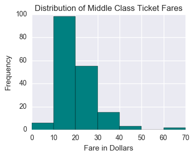

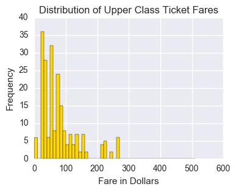

```python
fares_pclass = sanitized_data[["Fare", "Pclass"]]

def fare_distribution_by_class(fares_class, pclass="Lower", color="grey", bin_width=10):
    class_fares = fares_class[fares_class["Pclass"] == pclass]["Fare"]
    bins = range(int(round(min(class_fares),-1)), int(round((max(class_fares)+10), -1)), bin_width)
    class_fares.plot.hist(color=color, figsize=(4,3), bins=bins, title=("Distribution of %s Class Ticket Fares" % pclass)).set_xlabel("Fare in Dollars")

fare_distribution_by_class(fares_pclass)
plt.figure()
fare_distribution_by_class(fares_pclass, pclass="Middle", color="Teal")
plt.figure()
fare_distribution_by_class(fares_pclass, pclass="Upper", color="Gold", bin_width=10)
```

```python
free_fares = fare_subset[fare_subset["Fare"] == 0]

# percentage denominator subsetted by Southhampton because grouppby shows only free tickets were from Southhampton
perc_free = float(len(free_fares))/len(fare_subset)

print "!: %s%s of fares were free, across all classes" % (round(perc_free*100, 2), "%")
free_fares.groupby(["Pclass"])["Fare"].count()
```

[output not shown]

```
!: 1.68% of fares were free, across all classes
```

```
Pclass
Lower     4
Middle    6
Upper     5
Name: Fare, dtype: int64
```